# Лабораторная работа №10

Основы работы с модулями ядра операционной системы

Люкшина Влада Алексеевна

112243022@pfur.ru

Российский университет дружбы народов

2025-11-07

## Цель работы

- Получить навыки работы с утилитами управления модулями ядра операционной системы.

## Задание

1. Продемонстрируйте навыки работы по управлению модулями ядра.
2. Продемонстрируйте навыки работы по загрузке модулей ядра с параметрами.

## Выполнение лабораторной работы

## Выполнение

- Запустим терминал и получим полномочия администратора. Посмотрим, какие устройства имеются в нашей системе и какие модули ядра с ними связаны.

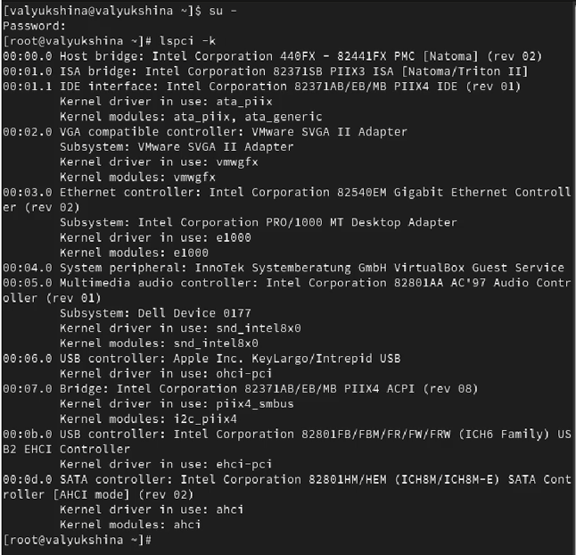

  !

## Выполнение

- Посмотрим, какие модули ядра загружены.

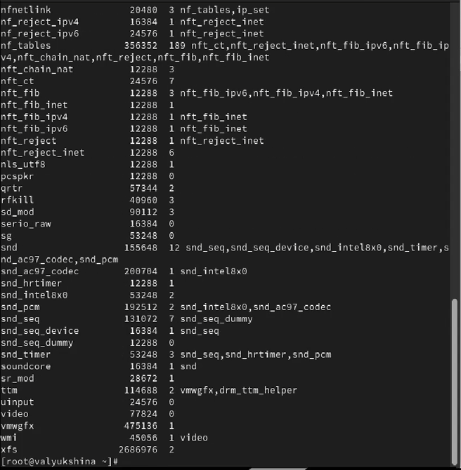

  !

## Выполнение

- Посмотрим, загружен ли модуль ext4. Он не загружен, поэтому загружаем модуль ядра ext4.

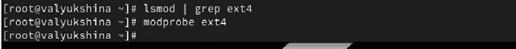

  !

## Выполнение

- Убедимся, что модуль загружен, посмотрев список загруженных модулей.

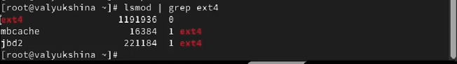

  !

## Выполнение

- Посмотрим информацию о модуле ядра ext4. Обратим внимание, что у этого модуля нет параметров, только основная информация с именем, авторами, лицензией и т.д.

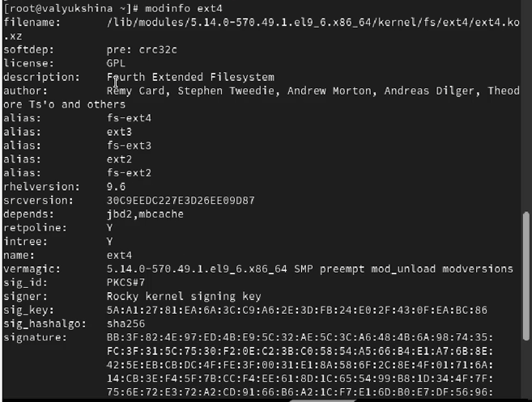

  !

## Выполнение

- Попробуем выгрузить модуль ядра ext4. Выводится фатальная ошибка, так как модуль в использовании. Потребуется ввести КОМАНДУ несколько раз.

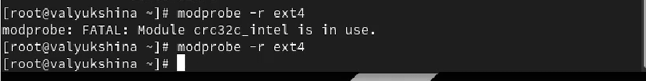

  !

## Выполнение

- Попробуем выгрузить модуль ядра xfs. Обратим внимание, что мы получим сообщение об ошибке, поскольку модуль ядра в данный момент используется.

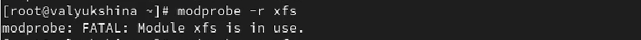

  !

## Выполнение

- Посмотрим, загружен ли модуль bluetooth. Он не загружен, поэтому загрузим его.

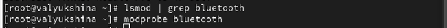

  !

## Выполнение

- Посмотрим список модулей ядра, отвечающих за работу с Bluetooth.

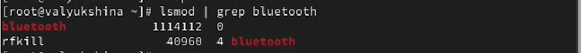

  !

## Выполнение

- Посмотрим информацию о модуле bluetooth, помимо основной информации о лицензии, авторах, имени и версии, также есть инфорация о парметрах.

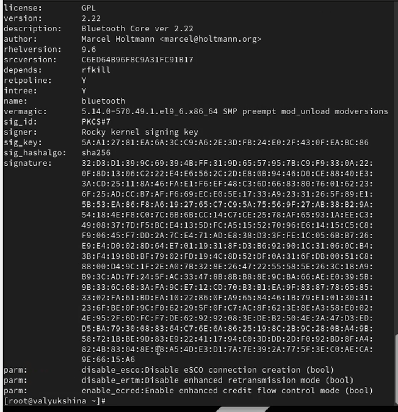

  !

## Выполнение

- Выгрузим модуль ядра bluetooth.

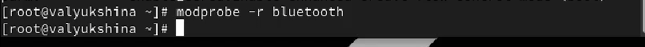

  !

## Выполнение

- Посмотрим версию ядра, используемую в операционной системе.

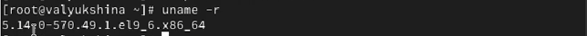

  !

## Выполнение

- Выведем на экран список пакетов, относящихся к ядру операционной системы.

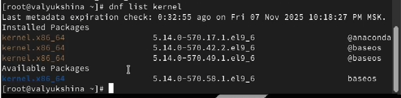

  !

## Выполнение

- Обновим систему, чтобы убедиться, что все существующие пакеты обновлены, так как это важно при установке/обновлении ядер Linux и избежания конфликтов.

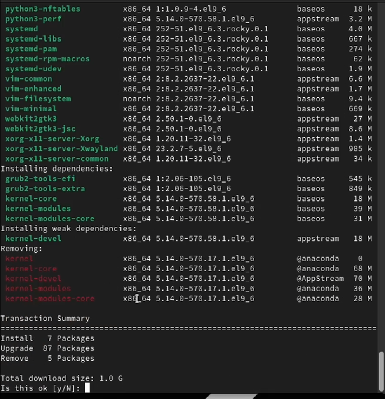

  !

## Выполнение

- Обновим ядро операционной системы, а затем саму операционную систему. Перезагрузим систему и выберем новое ядро.

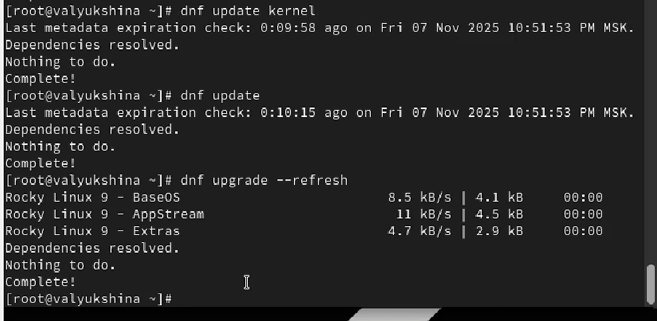

  !

## Выполнение

- Посмотрим версию ядра, используемую в операционной системе.

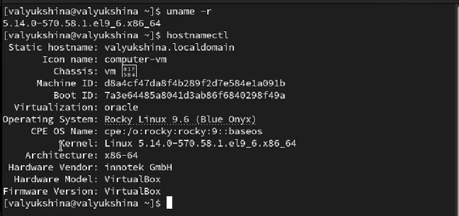

  !

## Выводы

- В лабораторной работе №10 мы научились работать с утилитами управления модулями ядра операционной си- стемы, выборочно выгружать и управлять ими.